# Risk Factor Analysis

## Outcome Variable

**Outcome Variable:** wast_rec90d

## Predictor Variables

**Intervention Variable:** perdiar6

**Adjustment Set:**

- arm
- sex
- W_mage
- meducyrs
- W_mhtcm
- W_mwtkg
- W_mbmi
- W_birthwt
- W_birthlen
- W_nrooms
- month
- brthmon
- impfloor
- impsan
- safeh20
- delta_W_mage
- delta_meducyrs
- delta_W_mhtcm
- delta_W_mwtkg
- delta_W_mbmi
- delta_W_birthwt
- delta_W_birthlen
- delta_W_nrooms
- delta_month
- delta_brthmon
- delta_impfloor
- delta_impsan
- delta_safeh20

## Stratifying Variables

The analysis was stratified on these variable(s):

- agecat
- studyid
- country

## Data Summary

| agecat | studyid | country | perdiar6 | wast_rec90d | n_cell | n |
| --- | --- | --- | --- | --- | --- | --- |
| 0-24 months | ki0047075b-MAL-ED | BANGLADESH | 0% | 0 | 17 | 124 |
| 0-24 months | ki0047075b-MAL-ED | BANGLADESH | 0% | 1 | 21 | 124 |
| 0-24 months | ki0047075b-MAL-ED | BANGLADESH | (0%, 5%] | 0 | 20 | 124 |
| 0-24 months | ki0047075b-MAL-ED | BANGLADESH | (0%, 5%] | 1 | 34 | 124 |
| 0-24 months | ki0047075b-MAL-ED | BANGLADESH | >5% | 0 | 8 | 124 |
| 0-24 months | ki0047075b-MAL-ED | BANGLADESH | >5% | 1 | 24 | 124 |
| 0-24 months | ki0047075b-MAL-ED | BRAZIL | 0% | 0 | 5 | 23 |
| 0-24 months | ki0047075b-MAL-ED | BRAZIL | 0% | 1 | 15 | 23 |
| 0-24 months | ki0047075b-MAL-ED | BRAZIL | (0%, 5%] | 0 | 0 | 23 |
| 0-24 months | ki0047075b-MAL-ED | BRAZIL | (0%, 5%] | 1 | 2 | 23 |
| 0-24 months | ki0047075b-MAL-ED | BRAZIL | >5% | 0 | 1 | 23 |
| 0-24 months | ki0047075b-MAL-ED | BRAZIL | >5% | 1 | 0 | 23 |
| 0-24 months | ki0047075b-MAL-ED | INDIA | 0% | 0 | 14 | 178 |
| 0-24 months | ki0047075b-MAL-ED | INDIA | 0% | 1 | 28 | 178 |
| 0-24 months | ki0047075b-MAL-ED | INDIA | (0%, 5%] | 0 | 35 | 178 |
| 0-24 months | ki0047075b-MAL-ED | INDIA | (0%, 5%] | 1 | 48 | 178 |
| 0-24 months | ki0047075b-MAL-ED | INDIA | >5% | 0 | 22 | 178 |
| 0-24 months | ki0047075b-MAL-ED | INDIA | >5% | 1 | 31 | 178 |
| 0-24 months | ki0047075b-MAL-ED | NEPAL | 0% | 0 | 12 | 93 |
| 0-24 months | ki0047075b-MAL-ED | NEPAL | 0% | 1 | 30 | 93 |
| 0-24 months | ki0047075b-MAL-ED | NEPAL | (0%, 5%] | 0 | 2 | 93 |
| 0-24 months | ki0047075b-MAL-ED | NEPAL | (0%, 5%] | 1 | 21 | 93 |
| 0-24 months | ki0047075b-MAL-ED | NEPAL | >5% | 0 | 6 | 93 |
| 0-24 months | ki0047075b-MAL-ED | NEPAL | >5% | 1 | 22 | 93 |
| 0-24 months | ki0047075b-MAL-ED | PERU | 0% | 0 | 3 | 34 |
| 0-24 months | ki0047075b-MAL-ED | PERU | 0% | 1 | 8 | 34 |
| 0-24 months | ki0047075b-MAL-ED | PERU | (0%, 5%] | 0 | 1 | 34 |
| 0-24 months | ki0047075b-MAL-ED | PERU | (0%, 5%] | 1 | 6 | 34 |
| 0-24 months | ki0047075b-MAL-ED | PERU | >5% | 0 | 2 | 34 |
| 0-24 months | ki0047075b-MAL-ED | PERU | >5% | 1 | 14 | 34 |

[output cut: 258 more lines]

The following strata were considered:

- agecat: 0-24 months, studyid: ki0047075b-MAL-ED, country: BANGLADESH
- agecat: 0-24 months, studyid: ki0047075b-MAL-ED, country: BRAZIL
- agecat: 0-24 months, studyid: ki0047075b-MAL-ED, country: INDIA
- agecat: 0-24 months, studyid: ki0047075b-MAL-ED, country: NEPAL
- agecat: 0-24 months, studyid: ki0047075b-MAL-ED, country: PERU
- agecat: 0-24 months, studyid: ki0047075b-MAL-ED, country: SOUTH AFRICA
- agecat: 0-24 months, studyid: ki0047075b-MAL-ED, country: TANZANIA, UNITED REPUBLIC OF
- agecat: 0-24 months, studyid: ki1000109-ResPak, country: PAKISTAN
- agecat: 0-24 months, studyid: ki1017093-NIH-Birth, country: BANGLADESH
- agecat: 0-24 months, studyid: ki1017093b-PROVIDE, country: BANGLADESH
- agecat: 0-24 months, studyid: ki1017093c-NIH-Crypto, country: BANGLADESH
- agecat: 0-24 months, studyid: ki1114097-CMIN, country: BANGLADESH
- agecat: 0-24 months, studyid: ki1114097-CMIN, country: BRAZIL
- agecat: 0-24 months, studyid: ki1114097-CMIN, country: GUINEA-BISSAU
- agecat: 0-24 months, studyid: ki1114097-CMIN, country: PERU
- agecat: 0-24 months, studyid: ki1114097-CONTENT, country: PERU
- agecat: 0-6 months, studyid: ki0047075b-MAL-ED, country: BANGLADESH
- agecat: 0-6 months, studyid: ki0047075b-MAL-ED, country: BRAZIL
- agecat: 0-6 months, studyid: ki0047075b-MAL-ED, country: INDIA
- agecat: 0-6 months, studyid: ki0047075b-MAL-ED, country: NEPAL
- agecat: 0-6 months, studyid: ki0047075b-MAL-ED, country: PERU
- agecat: 0-6 months, studyid: ki0047075b-MAL-ED, country: SOUTH AFRICA
- agecat: 0-6 months, studyid: ki0047075b-MAL-ED, country: TANZANIA, UNITED REPUBLIC OF
- agecat: 0-6 months, studyid: ki1000109-ResPak, country: PAKISTAN
- agecat: 0-6 months, studyid: ki1017093-NIH-Birth, country: BANGLADESH
- agecat: 0-6 months, studyid: ki1017093b-PROVIDE, country: BANGLADESH
- agecat: 0-6 months, studyid: ki1017093c-NIH-Crypto, country: BANGLADESH
- agecat: 0-6 months, studyid: ki1114097-CMIN, country: BANGLADESH
- agecat: 0-6 months, studyid: ki1114097-CMIN, country: BRAZIL
- agecat: 0-6 months, studyid: ki1114097-CMIN, country: GUINEA-BISSAU
- agecat: 0-6 months, studyid: ki1114097-CMIN, country: PERU
- agecat: 0-6 months, studyid: ki1114097-CONTENT, country: PERU
- agecat: 6-24 months, studyid: ki0047075b-MAL-ED, country: BANGLADESH
- agecat: 6-24 months, studyid: ki0047075b-MAL-ED, country: BRAZIL
- agecat: 6-24 months, studyid: ki0047075b-MAL-ED, country: INDIA
- agecat: 6-24 months, studyid: ki0047075b-MAL-ED, country: NEPAL
- agecat: 6-24 months, studyid: ki0047075b-MAL-ED, country: PERU
- agecat: 6-24 months, studyid: ki0047075b-MAL-ED, country: SOUTH AFRICA
- agecat: 6-24 months, studyid: ki0047075b-MAL-ED, country: TANZANIA, UNITED REPUBLIC OF
- agecat: 6-24 months, studyid: ki1000109-ResPak, country: PAKISTAN
- agecat: 6-24 months, studyid: ki1017093-NIH-Birth, country: BANGLADESH
- agecat: 6-24 months, studyid: ki1017093b-PROVIDE, country: BANGLADESH
- agecat: 6-24 months, studyid: ki1017093c-NIH-Crypto, country: BANGLADESH
- agecat: 6-24 months, studyid: ki1114097-CMIN, country: BANGLADESH
- agecat: 6-24 months, studyid: ki1114097-CMIN, country: BRAZIL
- agecat: 6-24 months, studyid: ki1114097-CMIN, country: GUINEA-BISSAU
- agecat: 6-24 months, studyid: ki1114097-CMIN, country: PERU
- agecat: 6-24 months, studyid: ki1114097-CONTENT, country: PERU

### Dropped Strata

Some strata were dropped due to rare outcomes:

- agecat: 0-24 months, studyid: ki0047075b-MAL-ED, country: BRAZIL
- agecat: 0-24 months, studyid: ki0047075b-MAL-ED, country: NEPAL
- agecat: 0-24 months, studyid: ki0047075b-MAL-ED, country: PERU
- agecat: 0-24 months, studyid: ki0047075b-MAL-ED, country: SOUTH AFRICA
- agecat: 0-24 months, studyid: ki0047075b-MAL-ED, country: TANZANIA, UNITED REPUBLIC OF
- agecat: 0-24 months, studyid: ki1114097-CMIN, country: BRAZIL
- agecat: 0-24 months, studyid: ki1114097-CMIN, country: PERU
- agecat: 0-24 months, studyid: ki1114097-CONTENT, country: PERU
- agecat: 0-6 months, studyid: ki0047075b-MAL-ED, country: BANGLADESH
- agecat: 0-6 months, studyid: ki0047075b-MAL-ED, country: BRAZIL
- agecat: 0-6 months, studyid: ki0047075b-MAL-ED, country: NEPAL
- agecat: 0-6 months, studyid: ki0047075b-MAL-ED, country: PERU
- agecat: 0-6 months, studyid: ki0047075b-MAL-ED, country: SOUTH AFRICA
- agecat: 0-6 months, studyid: ki0047075b-MAL-ED, country: TANZANIA, UNITED REPUBLIC OF
- agecat: 0-6 months, studyid: ki1114097-CMIN, country: BRAZIL
- agecat: 0-6 months, studyid: ki1114097-CMIN, country: GUINEA-BISSAU
- agecat: 0-6 months, studyid: ki1114097-CMIN, country: PERU
- agecat: 0-6 months, studyid: ki1114097-CONTENT, country: PERU
- agecat: 6-24 months, studyid: ki0047075b-MAL-ED, country: BRAZIL
- agecat: 6-24 months, studyid: ki0047075b-MAL-ED, country: NEPAL
- agecat: 6-24 months, studyid: ki0047075b-MAL-ED, country: PERU
- agecat: 6-24 months, studyid: ki0047075b-MAL-ED, country: SOUTH AFRICA
- agecat: 6-24 months, studyid: ki0047075b-MAL-ED, country: TANZANIA, UNITED REPUBLIC OF
- agecat: 6-24 months, studyid: ki1000109-ResPak, country: PAKISTAN
- agecat: 6-24 months, studyid: ki1017093c-NIH-Crypto, country: BANGLADESH
- agecat: 6-24 months, studyid: ki1114097-CMIN, country: BRAZIL
- agecat: 6-24 months, studyid: ki1114097-CMIN, country: PERU
- agecat: 6-24 months, studyid: ki1114097-CONTENT, country: PERU

## Methods Detail

We’re interested in the causal parameters $E[Y_a]$ for all values of $a \in \mathcal{A}$. These parameters represent the mean outcome if, possibly contrary to fact, we intervened to set all units to have $A=a$. Under the randomization and positivity assumptions, these are identified by the statistical parameters $\psi_a=E_W[E_{Y|A,W}(Y|A=a,W)]$. In addition, we’re interested in the mean of $Y$, $E[Y]$ under no intervention (the observed mean). We will estimate these parameters by using SuperLearner to fit the relevant likelihood factors – $E_{Y|A,W}(Y|A=a,W)$ and $p(A=a|W)$, and then updating our likelihood fit using a joint TMLE.

For unadjusted analyses ($W=\{\}$), initial likelihoods were estimated using Lrnr_glm to estimate the simple $E(Y|A)$ and Lrnr_mean to estimate $p(A)$. For adjusted analyses, a small library containing Lrnr_glmnet, Lrnr_xgboost, and Lrnr_mean was used.

Having estimated these parameters, we will then use the delta method to estimate relative risks and attributable risks relative to a prespecified baseline level of $A$.

# Results Detail

## Results Plots

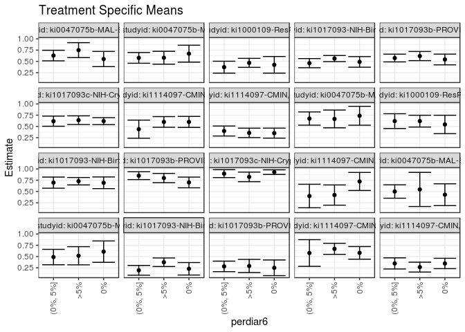

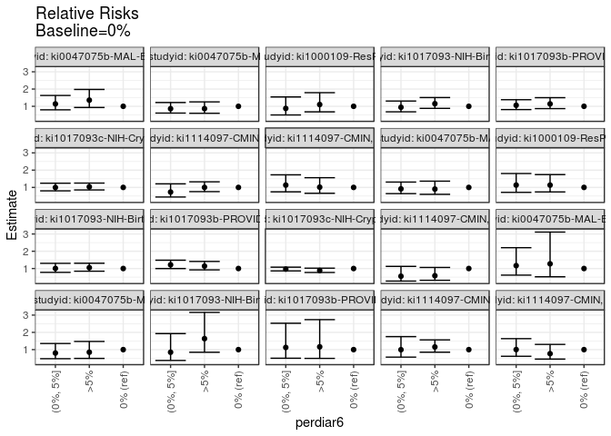

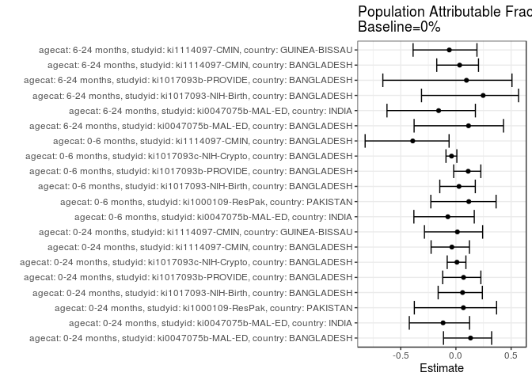

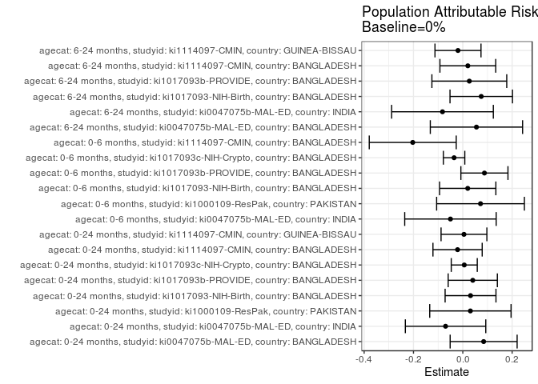

## Results Table

### Parameter: TSM

| agecat | studyid | country | intervention_level | baseline_level | estimate | ci_lower | ci_upper |
| --- | --- | --- | --- | --- | --- | --- | --- |
| 0-24 months | ki0047075b-MAL-ED | BANGLADESH | 0% | NA | 0.5526316 | 0.3844057 | 0.7208575 |
| 0-24 months | ki0047075b-MAL-ED | BANGLADESH | (0%, 5%] | NA | 0.6296296 | 0.5121519 | 0.7471074 |
| 0-24 months | ki0047075b-MAL-ED | BANGLADESH | >5% | NA | 0.7500000 | 0.5844253 | 0.9155747 |
| 0-24 months | ki0047075b-MAL-ED | INDIA | 0% | NA | 0.6710531 | 0.4830551 | 0.8590512 |
| 0-24 months | ki0047075b-MAL-ED | INDIA | (0%, 5%] | NA | 0.5779812 | 0.4591755 | 0.6967870 |
| 0-24 months | ki0047075b-MAL-ED | INDIA | >5% | NA | 0.5808602 | 0.4382425 | 0.7234779 |
| 0-24 months | ki1000109-ResPak | PAKISTAN | 0% | NA | 0.4242479 | 0.2400122 | 0.6084837 |
| 0-24 months | ki1000109-ResPak | PAKISTAN | (0%, 5%] | NA | 0.3721081 | 0.2398137 | 0.5044024 |
| 0-24 months | ki1000109-ResPak | PAKISTAN | >5% | NA | 0.4676879 | 0.3679265 | 0.5674492 |
| 0-24 months | ki1017093-NIH-Birth | BANGLADESH | 0% | NA | 0.4888333 | 0.3714401 | 0.6062266 |
| 0-24 months | ki1017093-NIH-Birth | BANGLADESH | (0%, 5%] | NA | 0.4611038 | 0.3597316 | 0.5624760 |
| 0-24 months | ki1017093-NIH-Birth | BANGLADESH | >5% | NA | 0.5630808 | 0.4948413 | 0.6313202 |
| 0-24 months | ki1017093b-PROVIDE | BANGLADESH | 0% | NA | 0.5426559 | 0.4233607 | 0.6619510 |
| 0-24 months | ki1017093b-PROVIDE | BANGLADESH | (0%, 5%] | NA | 0.5746854 | 0.4887011 | 0.6606697 |
| 0-24 months | ki1017093b-PROVIDE | BANGLADESH | >5% | NA | 0.6187688 | 0.5173401 | 0.7201975 |
| 0-24 months | ki1017093c-NIH-Crypto | BANGLADESH | 0% | NA | 0.6179140 | 0.5407874 | 0.6950406 |
| 0-24 months | ki1017093c-NIH-Crypto | BANGLADESH | (0%, 5%] | NA | 0.6164437 | 0.5041899 | 0.7286974 |
| 0-24 months | ki1017093c-NIH-Crypto | BANGLADESH | >5% | NA | 0.6388206 | 0.5427580 | 0.7348833 |
| 0-24 months | ki1114097-CMIN | BANGLADESH | 0% | NA | 0.6001778 | 0.4777823 | 0.7225732 |
| 0-24 months | ki1114097-CMIN | BANGLADESH | (0%, 5%] | NA | 0.4392212 | 0.2376585 | 0.6407839 |
| 0-24 months | ki1114097-CMIN | BANGLADESH | >5% | NA | 0.5999060 | 0.4811203 | 0.7186916 |
| 0-24 months | ki1114097-CMIN | GUINEA-BISSAU | 0% | NA | 0.3518655 | 0.2407371 | 0.4629940 |
| 0-24 months | ki1114097-CMIN | GUINEA-BISSAU | (0%, 5%] | NA | 0.3990432 | 0.2883371 | 0.5097492 |
| 0-24 months | ki1114097-CMIN | GUINEA-BISSAU | >5% | NA | 0.3569689 | 0.2522443 | 0.4616934 |
| 0-6 months | ki0047075b-MAL-ED | INDIA | 0% | NA | 0.7368421 | 0.5274868 | 0.9461974 |
| 0-6 months | ki0047075b-MAL-ED | INDIA | (0%, 5%] | NA | 0.6750000 | 0.5281850 | 0.8218150 |
| 0-6 months | ki0047075b-MAL-ED | INDIA | >5% | NA | 0.6666667 | 0.4693684 | 0.8639649 |
| 0-6 months | ki1000109-ResPak | PAKISTAN | 0% | NA | 0.5442552 | 0.3403177 | 0.7481928 |
| 0-6 months | ki1000109-ResPak | PAKISTAN | (0%, 5%] | NA | 0.6182241 | 0.4542530 | 0.7821952 |
| 0-6 months | ki1000109-ResPak | PAKISTAN | >5% | NA | 0.6172032 | 0.4864713 | 0.7479351 |
| 0-6 months | ki1017093-NIH-Birth | BANGLADESH | 0% | NA | 0.6930424 | 0.5637256 | 0.8223593 |
| 0-6 months | ki1017093-NIH-Birth | BANGLADESH | (0%, 5%] | NA | 0.6965872 | 0.5732370 | 0.8199374 |
| 0-6 months | ki1017093-NIH-Birth | BANGLADESH | >5% | NA | 0.7279665 | 0.6460205 | 0.8099125 |
| 0-6 months | ki1017093b-PROVIDE | BANGLADESH | 0% | NA | 0.7003800 | 0.5817657 | 0.8189944 |
| 0-6 months | ki1017093b-PROVIDE | BANGLADESH | (0%, 5%] | NA | 0.8511495 | 0.7640924 | 0.9382066 |
| 0-6 months | ki1017093b-PROVIDE | BANGLADESH | >5% | NA | 0.7979673 | 0.6951035 | 0.9008311 |
| 0-6 months | ki1017093c-NIH-Crypto | BANGLADESH | 0% | NA | 0.9292929 | 0.8781930 | 0.9803929 |
| 0-6 months | ki1017093c-NIH-Crypto | BANGLADESH | (0%, 5%] | NA | 0.8958333 | 0.8083097 | 0.9833570 |
| 0-6 months | ki1017093c-NIH-Crypto | BANGLADESH | >5% | NA | 0.8235294 | 0.7175654 | 0.9294935 |
| 0-6 months | ki1114097-CMIN | BANGLADESH | 0% | NA | 0.7222222 | 0.5220936 | 0.9223508 |
| 0-6 months | ki1114097-CMIN | BANGLADESH | (0%, 5%] | NA | 0.4000000 | 0.1395476 | 0.6604524 |
| 0-6 months | ki1114097-CMIN | BANGLADESH | >5% | NA | 0.4210526 | 0.1965983 | 0.6455070 |
| 6-24 months | ki0047075b-MAL-ED | BANGLADESH | 0% | NA | 0.4285714 | 0.1873815 | 0.6697613 |
| 6-24 months | ki0047075b-MAL-ED | BANGLADESH | (0%, 5%] | NA | 0.5000000 | 0.3511323 | 0.6488677 |
| 6-24 months | ki0047075b-MAL-ED | BANGLADESH | >5% | NA | 0.5454545 | 0.1667926 | 0.9241165 |
| 6-24 months | ki0047075b-MAL-ED | INDIA | 0% | NA | 0.6086957 | 0.3716126 | 0.8457787 |
| 6-24 months | ki0047075b-MAL-ED | INDIA | (0%, 5%] | NA | 0.4883721 | 0.3173946 | 0.6593495 |
| 6-24 months | ki0047075b-MAL-ED | INDIA | >5% | NA | 0.5172414 | 0.3159219 | 0.7185608 |
| 6-24 months | ki1017093-NIH-Birth | BANGLADESH | 0% | NA | 0.2282992 | 0.0898603 | 0.3667381 |
| 6-24 months | ki1017093-NIH-Birth | BANGLADESH | (0%, 5%] | NA | 0.1937633 | 0.0855489 | 0.3019778 |
| 6-24 months | ki1017093-NIH-Birth | BANGLADESH | >5% | NA | 0.3734134 | 0.2784207 | 0.4684062 |
| 6-24 months | ki1017093b-PROVIDE | BANGLADESH | 0% | NA | 0.2500000 | 0.0764031 | 0.4235969 |
| 6-24 months | ki1017093b-PROVIDE | BANGLADESH | (0%, 5%] | NA | 0.2812500 | 0.1643962 | 0.3981038 |
| 6-24 months | ki1017093b-PROVIDE | BANGLADESH | >5% | NA | 0.2903226 | 0.1444416 | 0.4362035 |
| 6-24 months | ki1114097-CMIN | BANGLADESH | 0% | NA | 0.5810705 | 0.4410183 | 0.7211227 |
| 6-24 months | ki1114097-CMIN | BANGLADESH | (0%, 5%] | NA | 0.5784079 | 0.2824518 | 0.8743640 |
| 6-24 months | ki1114097-CMIN | BANGLADESH | >5% | NA | 0.6707231 | 0.5478634 | 0.7935828 |
| 6-24 months | ki1114097-CMIN | GUINEA-BISSAU | 0% | NA | 0.3461803 | 0.2310727 | 0.4612879 |
| 6-24 months | ki1114097-CMIN | GUINEA-BISSAU | (0%, 5%] | NA | 0.3472186 | 0.2235765 | 0.4708606 |
| 6-24 months | ki1114097-CMIN | GUINEA-BISSAU | >5% | NA | 0.2651712 | 0.1558193 | 0.3745232 |

### Parameter: E(Y)

| agecat | studyid | country | intervention_level | baseline_level | estimate | ci_lower | ci_upper |
| --- | --- | --- | --- | --- | --- | --- | --- |
| 0-24 months | ki0047075b-MAL-ED | BANGLADESH | NA | NA | 0.6370968 | 0.5511492 | 0.7230443 |
| 0-24 months | ki0047075b-MAL-ED | INDIA | NA | NA | 0.6011236 | 0.5212729 | 0.6809743 |
| 0-24 months | ki1000109-ResPak | PAKISTAN | NA | NA | 0.4550000 | 0.3826235 | 0.5273765 |
| 0-24 months | ki1017093-NIH-Birth | BANGLADESH | NA | NA | 0.5201900 | 0.4695846 | 0.5707955 |
| 0-24 months | ki1017093b-PROVIDE | BANGLADESH | NA | NA | 0.5830619 | 0.5262762 | 0.6398476 |
| 0-24 months | ki1017093c-NIH-Crypto | BANGLADESH | NA | NA | 0.6237942 | 0.5698223 | 0.6777662 |
| 0-24 months | ki1114097-CMIN | BANGLADESH | NA | NA | 0.5789474 | 0.5004470 | 0.6574477 |
| 0-24 months | ki1114097-CMIN | GUINEA-BISSAU | NA | NA | 0.3565574 | 0.2946037 | 0.4185110 |
| 0-6 months | ki0047075b-MAL-ED | INDIA | NA | NA | 0.6867470 | 0.5837430 | 0.7897510 |
| 0-6 months | ki1000109-ResPak | PAKISTAN | NA | NA | 0.6160714 | 0.5252688 | 0.7068741 |
| 0-6 months | ki1017093-NIH-Birth | BANGLADESH | NA | NA | 0.7130045 | 0.6535890 | 0.7724200 |
| 0-6 months | ki1017093b-PROVIDE | BANGLADESH | NA | NA | 0.7880435 | 0.7295878 | 0.8464992 |
| 0-6 months | ki1017093c-NIH-Crypto | BANGLADESH | NA | NA | 0.8939394 | 0.8505280 | 0.9373508 |
| 0-6 months | ki1114097-CMIN | BANGLADESH | NA | NA | 0.5192308 | 0.3806687 | 0.6577929 |
| 6-24 months | ki0047075b-MAL-ED | BANGLADESH | NA | NA | 0.4838710 | 0.3544124 | 0.6133295 |
| 6-24 months | ki0047075b-MAL-ED | INDIA | NA | NA | 0.5263158 | 0.4116286 | 0.6410029 |
| 6-24 months | ki1017093-NIH-Birth | BANGLADESH | NA | NA | 0.3030303 | 0.2377927 | 0.3682679 |
| 6-24 months | ki1017093b-PROVIDE | BANGLADESH | NA | NA | 0.2764228 | 0.1950773 | 0.3577682 |
| 6-24 months | ki1114097-CMIN | BANGLADESH | NA | NA | 0.6014493 | 0.5131344 | 0.6897641 |
| 6-24 months | ki1114097-CMIN | GUINEA-BISSAU | NA | NA | 0.3266332 | 0.2609581 | 0.3923082 |

### Parameter: RR

| agecat | studyid | country | intervention_level | baseline_level | estimate | ci_lower | ci_upper |
| --- | --- | --- | --- | --- | --- | --- | --- |
| 0-24 months | ki0047075b-MAL-ED | BANGLADESH | 0% | 0% | 1.0000000 | 1.0000000 | 1.000000 |
| 0-24 months | ki0047075b-MAL-ED | BANGLADESH | (0%, 5%] | 0% | 1.1393298 | 0.7971261 | 1.628440 |
| 0-24 months | ki0047075b-MAL-ED | BANGLADESH | >5% | 0% | 1.3571429 | 0.9317025 | 1.976851 |
| 0-24 months | ki0047075b-MAL-ED | INDIA | 0% | 0% | 1.0000000 | 1.0000000 | 1.000000 |
| 0-24 months | ki0047075b-MAL-ED | INDIA | (0%, 5%] | 0% | 0.8613047 | 0.6084050 | 1.219329 |
| 0-24 months | ki0047075b-MAL-ED | INDIA | >5% | 0% | 0.8655950 | 0.5963025 | 1.256501 |
| 0-24 months | ki1000109-ResPak | PAKISTAN | 0% | 0% | 1.0000000 | 1.0000000 | 1.000000 |
| 0-24 months | ki1000109-ResPak | PAKISTAN | (0%, 5%] | 0% | 0.8771004 | 0.4990129 | 1.541654 |
| 0-24 months | ki1000109-ResPak | PAKISTAN | >5% | 0% | 1.1023928 | 0.6791086 | 1.789507 |
| 0-24 months | ki1017093-NIH-Birth | BANGLADESH | 0% | 0% | 1.0000000 | 1.0000000 | 1.000000 |
| 0-24 months | ki1017093-NIH-Birth | BANGLADESH | (0%, 5%] | 0% | 0.9432741 | 0.6816605 | 1.305292 |
| 0-24 months | ki1017093-NIH-Birth | BANGLADESH | >5% | 0% | 1.1518870 | 0.8807414 | 1.506508 |
| 0-24 months | ki1017093b-PROVIDE | BANGLADESH | 0% | 0% | 1.0000000 | 1.0000000 | 1.000000 |
| 0-24 months | ki1017093b-PROVIDE | BANGLADESH | (0%, 5%] | 0% | 1.0590236 | 0.8117803 | 1.381570 |
| 0-24 months | ki1017093b-PROVIDE | BANGLADESH | >5% | 0% | 1.1402600 | 0.8670545 | 1.499552 |
| 0-24 months | ki1017093c-NIH-Crypto | BANGLADESH | 0% | 0% | 1.0000000 | 1.0000000 | 1.000000 |
| 0-24 months | ki1017093c-NIH-Crypto | BANGLADESH | (0%, 5%] | 0% | 0.9976205 | 0.8004060 | 1.243427 |
| 0-24 months | ki1017093c-NIH-Crypto | BANGLADESH | >5% | 0% | 1.0338343 | 0.8542226 | 1.251212 |
| 0-24 months | ki1114097-CMIN | BANGLADESH | 0% | 0% | 1.0000000 | 1.0000000 | 1.000000 |
| 0-24 months | ki1114097-CMIN | BANGLADESH | (0%, 5%] | 0% | 0.7318185 | 0.4438526 | 1.206613 |
| 0-24 months | ki1114097-CMIN | BANGLADESH | >5% | 0% | 0.9995472 | 0.7548411 | 1.323583 |
| 0-24 months | ki1114097-CMIN | GUINEA-BISSAU | 0% | 0% | 1.0000000 | 1.0000000 | 1.000000 |
| 0-24 months | ki1114097-CMIN | GUINEA-BISSAU | (0%, 5%] | 0% | 1.1340786 | 0.7436325 | 1.729529 |
| 0-24 months | ki1114097-CMIN | GUINEA-BISSAU | >5% | 0% | 1.0145036 | 0.6590802 | 1.561597 |
| 0-6 months | ki0047075b-MAL-ED | INDIA | 0% | 0% | 1.0000000 | 1.0000000 | 1.000000 |
| 0-6 months | ki0047075b-MAL-ED | INDIA | (0%, 5%] | 0% | 0.9160714 | 0.6405164 | 1.310172 |
| 0-6 months | ki0047075b-MAL-ED | INDIA | >5% | 0% | 0.9047619 | 0.6002904 | 1.363664 |
| 0-6 months | ki1000109-ResPak | PAKISTAN | 0% | 0% | 1.0000000 | 1.0000000 | 1.000000 |
| 0-6 months | ki1000109-ResPak | PAKISTAN | (0%, 5%] | 0% | 1.1359085 | 0.7146113 | 1.805580 |
| 0-6 months | ki1000109-ResPak | PAKISTAN | >5% | 0% | 1.1340327 | 0.7376285 | 1.743466 |
| 0-6 months | ki1017093-NIH-Birth | BANGLADESH | 0% | 0% | 1.0000000 | 1.0000000 | 1.000000 |
| 0-6 months | ki1017093-NIH-Birth | BANGLADESH | (0%, 5%] | 0% | 1.0051148 | 0.7774433 | 1.299459 |
| 0-6 months | ki1017093-NIH-Birth | BANGLADESH | >5% | 0% | 1.0503923 | 0.8448740 | 1.305904 |
| 0-6 months | ki1017093b-PROVIDE | BANGLADESH | 0% | 0% | 1.0000000 | 1.0000000 | 1.000000 |
| 0-6 months | ki1017093b-PROVIDE | BANGLADESH | (0%, 5%] | 0% | 1.2152681 | 0.9968493 | 1.481545 |
| 0-6 months | ki1017093b-PROVIDE | BANGLADESH | >5% | 0% | 1.1393347 | 0.9209745 | 1.409468 |
| 0-6 months | ki1017093c-NIH-Crypto | BANGLADESH | 0% | 0% | 1.0000000 | 1.0000000 | 1.000000 |
| 0-6 months | ki1017093c-NIH-Crypto | BANGLADESH | (0%, 5%] | 0% | 0.9639946 | 0.8617572 | 1.078361 |
| 0-6 months | ki1017093c-NIH-Crypto | BANGLADESH | >5% | 0% | 0.8861893 | 0.7704715 | 1.019287 |
| 0-6 months | ki1114097-CMIN | BANGLADESH | 0% | 0% | 1.0000000 | 1.0000000 | 1.000000 |
| 0-6 months | ki1114097-CMIN | BANGLADESH | (0%, 5%] | 0% | 0.5538462 | 0.2729382 | 1.123865 |
| 0-6 months | ki1114097-CMIN | BANGLADESH | >5% | 0% | 0.5829960 | 0.3197555 | 1.062950 |
| 6-24 months | ki0047075b-MAL-ED | BANGLADESH | 0% | 0% | 1.0000000 | 1.0000000 | 1.000000 |
| 6-24 months | ki0047075b-MAL-ED | BANGLADESH | (0%, 5%] | 0% | 1.1666667 | 0.6172192 | 2.205232 |
| 6-24 months | ki0047075b-MAL-ED | BANGLADESH | >5% | 0% | 1.2727273 | 0.5208739 | 3.109841 |
| 6-24 months | ki0047075b-MAL-ED | INDIA | 0% | 0% | 1.0000000 | 1.0000000 | 1.000000 |
| 6-24 months | ki0047075b-MAL-ED | INDIA | (0%, 5%] | 0% | 0.8023256 | 0.4751146 | 1.354887 |
| 6-24 months | ki0047075b-MAL-ED | INDIA | >5% | 0% | 0.8497537 | 0.4901748 | 1.473110 |
| 6-24 months | ki1017093-NIH-Birth | BANGLADESH | 0% | 0% | 1.0000000 | 1.0000000 | 1.000000 |
| 6-24 months | ki1017093-NIH-Birth | BANGLADESH | (0%, 5%] | 0% | 0.8487254 | 0.3735948 | 1.928118 |
| 6-24 months | ki1017093-NIH-Birth | BANGLADESH | >5% | 0% | 1.6356316 | 0.8476400 | 3.156164 |
| 6-24 months | ki1017093b-PROVIDE | BANGLADESH | 0% | 0% | 1.0000000 | 1.0000000 | 1.000000 |
| 6-24 months | ki1017093b-PROVIDE | BANGLADESH | (0%, 5%] | 0% | 1.1250000 | 0.5008452 | 2.526978 |
| 6-24 months | ki1017093b-PROVIDE | BANGLADESH | >5% | 0% | 1.1612903 | 0.4928137 | 2.736521 |
| 6-24 months | ki1114097-CMIN | BANGLADESH | 0% | 0% | 1.0000000 | 1.0000000 | 1.000000 |
| 6-24 months | ki1114097-CMIN | BANGLADESH | (0%, 5%] | 0% | 0.9954178 | 0.5654742 | 1.752258 |
| 6-24 months | ki1114097-CMIN | BANGLADESH | >5% | 0% | 1.1542887 | 0.8517801 | 1.564233 |
| 6-24 months | ki1114097-CMIN | GUINEA-BISSAU | 0% | 0% | 1.0000000 | 1.0000000 | 1.000000 |
| 6-24 months | ki1114097-CMIN | GUINEA-BISSAU | (0%, 5%] | 0% | 1.0029993 | 0.6156600 | 1.634031 |
| 6-24 months | ki1114097-CMIN | GUINEA-BISSAU | >5% | 0% | 0.7659918 | 0.4507811 | 1.301615 |

### Parameter: PAR

| agecat | studyid | country | intervention_level | baseline_level | estimate | ci_lower | ci_upper |
| --- | --- | --- | --- | --- | --- | --- | --- |
| 0-24 months | ki0047075b-MAL-ED | BANGLADESH | 0% | NA | 0.0844652 | -0.0513158 | 0.2202462 |
| 0-24 months | ki0047075b-MAL-ED | INDIA | 0% | NA | -0.0699295 | -0.2329990 | 0.0931400 |
| 0-24 months | ki1000109-ResPak | PAKISTAN | 0% | NA | 0.0307521 | -0.1341211 | 0.1956252 |
| 0-24 months | ki1017093-NIH-Birth | BANGLADESH | 0% | NA | 0.0313567 | -0.0717528 | 0.1344662 |
| 0-24 months | ki1017093b-PROVIDE | BANGLADESH | 0% | NA | 0.0404060 | -0.0592796 | 0.1400917 |
| 0-24 months | ki1017093c-NIH-Crypto | BANGLADESH | 0% | NA | 0.0058802 | -0.0468568 | 0.0586172 |
| 0-24 months | ki1114097-CMIN | BANGLADESH | 0% | NA | -0.0212304 | -0.1210361 | 0.0785753 |
| 0-24 months | ki1114097-CMIN | GUINEA-BISSAU | 0% | NA | 0.0046918 | -0.0881775 | 0.0975612 |
| 0-6 months | ki0047075b-MAL-ED | INDIA | 0% | NA | -0.0500951 | -0.2354944 | 0.1353041 |
| 0-6 months | ki1000109-ResPak | PAKISTAN | 0% | NA | 0.0718162 | -0.1060762 | 0.2497086 |
| 0-6 months | ki1017093-NIH-Birth | BANGLADESH | 0% | NA | 0.0199620 | -0.0941225 | 0.1340466 |
| 0-6 months | ki1017093b-PROVIDE | BANGLADESH | 0% | NA | 0.0876634 | -0.0077795 | 0.1831064 |
| 0-6 months | ki1017093c-NIH-Crypto | BANGLADESH | 0% | NA | -0.0353535 | -0.0787883 | 0.0080812 |
| 0-6 months | ki1114097-CMIN | BANGLADESH | 0% | NA | -0.2029915 | -0.3793059 | -0.0266770 |
| 6-24 months | ki0047075b-MAL-ED | BANGLADESH | 0% | NA | 0.0552995 | -0.1317965 | 0.2423956 |
| 6-24 months | ki0047075b-MAL-ED | INDIA | 0% | NA | -0.0823799 | -0.2885361 | 0.1237764 |
| 6-24 months | ki1017093-NIH-Birth | BANGLADESH | 0% | NA | 0.0747311 | -0.0518965 | 0.2013587 |
| 6-24 months | ki1017093b-PROVIDE | BANGLADESH | 0% | NA | 0.0264228 | -0.1253051 | 0.1781506 |
| 6-24 months | ki1114097-CMIN | BANGLADESH | 0% | NA | 0.0203788 | -0.0927436 | 0.1335012 |
| 6-24 months | ki1114097-CMIN | GUINEA-BISSAU | 0% | NA | -0.0195471 | -0.1128618 | 0.0737676 |

### Parameter: PAF

| agecat | studyid | country | intervention_level | baseline_level | estimate | ci_lower | ci_upper |
| --- | --- | --- | --- | --- | --- | --- | --- |
| 0-24 months | ki0047075b-MAL-ED | BANGLADESH | 0% | NA | 0.1325783 | -0.1123815 | 0.3235950 |
| 0-24 months | ki0047075b-MAL-ED | INDIA | 0% | NA | -0.1163314 | -0.4221690 | 0.1237358 |
| 0-24 months | ki1000109-ResPak | PAKISTAN | 0% | NA | 0.0675869 | -0.3765084 | 0.3684062 |
| 0-24 months | ki1017093-NIH-Birth | BANGLADESH | 0% | NA | 0.0602793 | -0.1609063 | 0.2393228 |
| 0-24 months | ki1017093b-PROVIDE | BANGLADESH | 0% | NA | 0.0692997 | -0.1193049 | 0.2261242 |
| 0-24 months | ki1017093c-NIH-Crypto | BANGLADESH | 0% | NA | 0.0094266 | -0.0788723 | 0.0904987 |
| 0-24 months | ki1114097-CMIN | BANGLADESH | 0% | NA | -0.0366707 | -0.2247372 | 0.1225170 |
| 0-24 months | ki1114097-CMIN | GUINEA-BISSAU | 0% | NA | 0.0131587 | -0.2848928 | 0.2420725 |
| 0-6 months | ki0047075b-MAL-ED | INDIA | 0% | NA | -0.0729455 | -0.3806231 | 0.1661648 |
| 0-6 months | ki1000109-ResPak | PAKISTAN | 0% | NA | 0.1165712 | -0.2269214 | 0.3638986 |
| 0-6 months | ki1017093-NIH-Birth | BANGLADESH | 0% | NA | 0.0279971 | -0.1459873 | 0.1755671 |
| 0-6 months | ki1017093b-PROVIDE | BANGLADESH | 0% | NA | 0.1112419 | -0.0201338 | 0.2256986 |
| 0-6 months | ki1017093c-NIH-Crypto | BANGLADESH | 0% | NA | -0.0395480 | -0.0899442 | 0.0085179 |
| 0-6 months | ki1114097-CMIN | BANGLADESH | 0% | NA | -0.3909465 | -0.8220742 | -0.0618295 |
| 6-24 months | ki0047075b-MAL-ED | BANGLADESH | 0% | NA | 0.1142857 | -0.3786277 | 0.4309633 |
| 6-24 months | ki0047075b-MAL-ED | INDIA | 0% | NA | -0.1565217 | -0.6242382 | 0.1765108 |
| 6-24 months | ki1017093-NIH-Birth | BANGLADESH | 0% | NA | 0.2466126 | -0.3114823 | 0.5672129 |
| 6-24 months | ki1017093b-PROVIDE | BANGLADESH | 0% | NA | 0.0955882 | -0.6617363 | 0.5077675 |
| 6-24 months | ki1114097-CMIN | BANGLADESH | 0% | NA | 0.0338828 | -0.1735393 | 0.2046432 |
| 6-24 months | ki1114097-CMIN | GUINEA-BISSAU | 0% | NA | -0.0598442 | -0.3877783 | 0.1905987 |